# Problem Statement

## Cuisine type

```python
# check unique cuisine type
df['cuisine_type'].nunique()
```

```
14
```

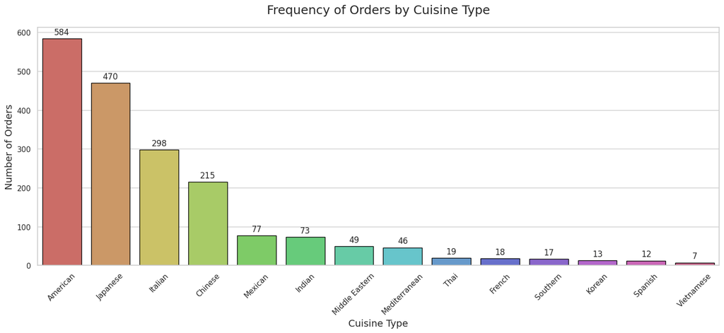

```python
# plot style
sns.set(style="whitegrid")

plt.figure(figsize=(15, 7))

# Determine the order of bars (sorting from highest to lowest count)
order_list = df['cuisine_type'].value_counts().index

# the Countplot
ax = sns.countplot(
    data=df,
    x='cuisine_type',
    order=order_list,       # Sort bars
    palette='hls',      # Use a colorful gradient palette
    edgecolor='black'       # Add border to bars for definition
)

# Title and Axis Labels
plt.title('Frequency of Orders by Cuisine Type', fontsize=18, weight='light', pad=20)
plt.xlabel('Cuisine Type', fontsize=14)
plt.ylabel('Number of Orders', fontsize=14)

# Rotate x-axis labels to avoid overlap if there are many categories
plt.xticks(rotation=45)

# data labels (counts) on top of each bar
for container in ax.containers:
    ax.bar_label(container, padding=3, fontsize=12, fontweight='light')

plt.tight_layout()
plt.show()
```

### 🔭 My Observations:

- The platform offers **14 distinct cuisine types**, indicating a diverse food portfolio.
- Order demand is **highly concentrated**, with **American, Japanese, Italian, and Chinese cuisines** accounting for the majority of orders.
- American cuisine is the most popular, followed by Japanese and Italian.
- Several cuisines exhibit **very low order frequency**, reflecting a long-tail demand pattern.
- This suggests opportunities for **focused marketing on high-demand cuisines** and **selective promotion** of niche cuisines.

## Cost of the order

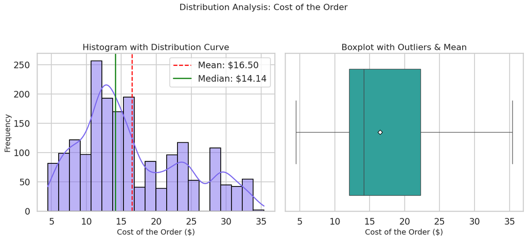

```python
# a clean style
sns.set(style="whitegrid", context="talk")

# a figure with a main title
plt.figure(figsize=(14, 6))
plt.suptitle('Distribution Analysis: Cost of the Order', fontsize=16, weight='light', y=1.05)

# --- Plot 1: Histogram with KDE and Stat Lines ---
plt.subplot(1, 2, 1)

# stats for lines
mean_val = df['cost_of_the_order'].mean()
median_val = df['cost_of_the_order'].median()

# Histogram with custom color and darker KDE line
sns.histplot(
    data=df,
    x='cost_of_the_order',
    kde=True,
    bins=20,
    color='mediumslateblue',
    edgecolor='black',
    line_kws={'linewidth': 2, 'color': 'darkblue'}
)

# vertical lines for Mean and Median
plt.axvline(mean_val, color='red', linestyle='--', linewidth=2, label=f'Mean: ${mean_val:.2f}')
plt.axvline(median_val, color='green', linestyle='-', linewidth=2, label=f'Median: ${median_val:.2f}')

# Labelling
plt.title('Histogram with Distribution Curve', fontsize=16)
plt.xlabel('Cost of the Order ($)', fontsize=14)
plt.ylabel('Frequency', fontsize=14)
plt.legend()  # Show the legend for Mean/Median lines

# --- Plot 2: Boxplot with Custom Outliers ---
plt.subplot(1, 2, 2)

# Boxplot with custom palette and outlier styling
sns.boxplot(
    data=df,
    x='cost_of_the_order',
    color='lightseagreen',
    flierprops={"marker": "o", "markerfacecolor": "red", "markersize": 6, "markeredgecolor": "black"},
    showmeans=True,
    meanprops={"marker": "D", "markerfacecolor": "white", "markeredgecolor": "black"}
)

# Labelling
plt.title('Boxplot with Outliers & Mean', fontsize=16)
plt.xlabel('Cost of the Order ($)', fontsize=14)

# Adjust layout to prevent overlap
plt.tight_layout()
plt.show()
```

## Day of the week

```python
# check the unique values
df['day_of_the_week'].value_counts()
```

| day_of_the_week | count |
| --- | --- |
| Weekend | 1351 |
| Weekday | 547 |

**dtype:** int64

```python
# Interactive Plotly Plot
```

```python
day_counts = df['day_of_the_week'].value_counts().reset_index()
day_counts.columns = ['Day Type', 'Orders']

fig = px.pie(
    day_counts,
    names='Day Type',
    values='Orders',
    hole=0.45,
    color_discrete_sequence=px.colors.qualitative.Set2,
    title='Order Distribution: Weekend vs Weekday'
)

fig.update_traces(textinfo='percent+label')
fig.update_layout(template='plotly_white')

fig.show()
```

[interactive chart not shown]

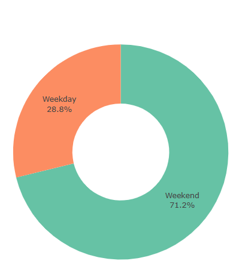

### 🔭 My Observations:

- A clear majority of orders (**~71%**) are placed on **weekends**, compared to **~29%** on weekdays.
- This indicates that FoodHub is predominantly a **weekend-driven platform**, likely tied to leisure-oriented consumption.
- The strong weekend skew highlights the importance of **capacity planning and promotions** during weekends to maximize revenue and service quality.

## Rating

```python
# check the unique values
df['rating'].value_counts()
```

| rating | count |
| --- | --- |
| Not given | 736 |
| 5 | 588 |
| 4 | 386 |
| 3 | 188 |

**dtype:** int64

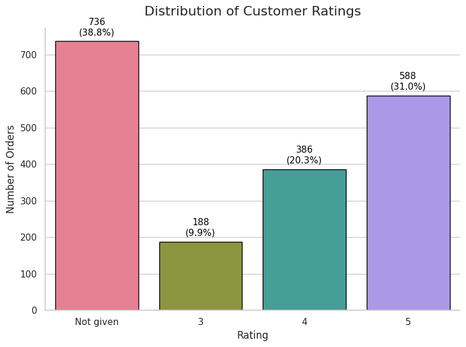

```python
# style
sns.set(style="whitegrid")

plt.figure(figsize=(8, 6))

# Order
# It is crucial to keep 'Not given' separate or at the start/end
rating_order = ['Not given', '3', '4', '5']

#  Countplot
ax = sns.countplot(
    data=df,
    x='rating',
    order=rating_order,
    palette='husl',
    edgecolor='black'
)

# Titles and Labels
plt.title('Distribution of Customer Ratings', fontsize=16, weight='light', pad=15)
plt.xlabel('Rating', fontsize=12)
plt.ylabel('Number of Orders', fontsize=12)

# Counts AND Percentages
# This is especially useful to see exactly what % of users did NOT give a rating
total = len(df)
for p in ax.patches:
    count = int(p.get_height())
    percentage = (count / total) * 100

    ax.annotate(f'{count}\n({percentage:.1f}%)',
                (p.get_x() + p.get_width() / 2., p.get_height()),
                ha='center', va='bottom',
                fontsize=11, fontweight='light', color='black',
                xytext=(0, 5), textcoords='offset points')

# Clean up layout
sns.despine()
plt.tight_layout()
plt.show()
```

### 🔭 My Observations:

- A substantial share of orders (**~39%**) are marked as **“Not given”**, indicating a significant feedback gap.
- Among rated orders, **high ratings dominate**, with **4-star and 5-star ratings** accounting for the majority.
- Low ratings (**3-star**) are relatively infrequent, suggesting generally **positive customer experiences**.
- The high proportion of unrated orders should be handled separately to avoid bias in customer satisfaction analysis.

## Food Preparation time

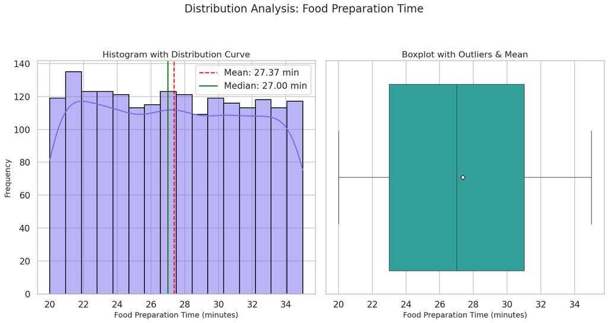

```python
# Set the style
sns.set(style="whitegrid", context="talk")

# Create figure with main title
plt.figure(figsize=(16, 8))
plt.suptitle('Distribution Analysis: Food Preparation Time', fontsize=20, weight='light', y=1.05)

# --- Plot 1: Histogram with KDE and Stat Lines ---
plt.subplot(1, 2, 1)

# Calculate stats for lines
mean_val = df['food_preparation_time'].mean()
median_val = df['food_preparation_time'].median()

# Histogram
sns.histplot(
    data=df,
    x='food_preparation_time',
    kde=True,
    bins=16,  # 16 bins works well for the 20-35 min range
    color='mediumslateblue',
    edgecolor='black',
    line_kws={'linewidth': 2, 'color': 'darkblue'}
)

# Vertical lines for Mean and Median
plt.axvline(mean_val, color='red', linestyle='--', linewidth=2, label=f'Mean: {mean_val:.2f} min')
plt.axvline(median_val, color='green', linestyle='-', linewidth=2, label=f'Median: {median_val:.2f} min')

# Labelling
plt.title('Histogram with Distribution Curve', fontsize=16)
plt.xlabel('Food Preparation Time (minutes)', fontsize=14)
plt.ylabel('Frequency', fontsize=14)
plt.legend()

# --- Plot 2: Boxplot with Custom Outliers ---
plt.subplot(1, 2, 2)

# Boxplot
sns.boxplot(
    data=df,
    x='food_preparation_time',
    color='lightseagreen',
    flierprops={"marker": "o", "markerfacecolor": "red", "markersize": 6, "markeredgecolor": "black"},
    showmeans=True,
    meanprops={"marker": "D", "markerfacecolor": "white", "markeredgecolor": "black"}
)

# Labelling
plt.title('Boxplot with Outliers & Mean', fontsize=16)
plt.xlabel('Food Preparation Time (minutes)', fontsize=14)

# Adjust layout
plt.tight_layout()
plt.show()
```

### 🔭 My Observations:

- Food preparation time is **centered around ~27 minutes**, with mean and median closely aligned, indicating a **stable distribution**.
- Most orders fall within the **20–35 minute** range, showing limited variability.
- No significant extreme outliers are observed, suggesting **consistent restaurant preparation performance**.
- This consistency provides a reliable baseline for end-to-end delivery time optimization.

## Delivery time

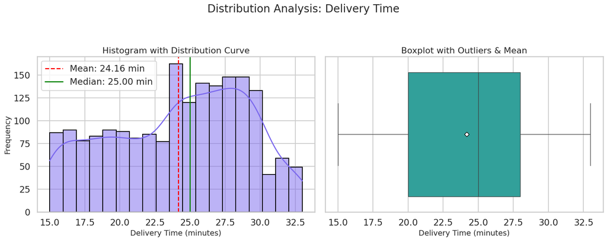

```python
# style
sns.set(style="whitegrid", context="talk")

# figure with main title
plt.figure(figsize=(16, 6))
plt.suptitle('Distribution Analysis: Delivery Time', fontsize=20, weight='light', y=1.05)

# --- Plot 1: Histogram with KDE and Stat Lines ---
plt.subplot(1, 2, 1)

# Calculate stats for lines
mean_val = df['delivery_time'].mean()
median_val = df['delivery_time'].median()

# Histogram
sns.histplot(
    data=df,
    x='delivery_time',
    kde=True,
    bins=19,
    color='mediumslateblue',
    edgecolor='black',
    line_kws={'linewidth': 2, 'color': 'darkblue'}
)

# Vertical lines for Mean and Median
plt.axvline(mean_val, color='red', linestyle='--', linewidth=2, label=f'Mean: {mean_val:.2f} min')
plt.axvline(median_val, color='green', linestyle='-', linewidth=2, label=f'Median: {median_val:.2f} min')

# Labelling
plt.title('Histogram with Distribution Curve', fontsize=16)
plt.xlabel('Delivery Time (minutes)', fontsize=14)
plt.ylabel('Frequency', fontsize=14)
plt.legend()

# --- Plot 2: Boxplot with Custom Outliers ---
plt.subplot(1, 2, 2)

# Boxplot
sns.boxplot(
    data=df,
    x='delivery_time',
    color='lightseagreen',
    flierprops={"marker": "o", "markerfacecolor": "red", "markersize": 6, "markeredgecolor": "black"},
    showmeans=True,
    meanprops={"marker": "D", "markerfacecolor": "white", "markeredgecolor": "black"}
)

# Labelling
plt.title('Boxplot with Outliers & Mean', fontsize=16)
plt.xlabel('Delivery Time (minutes)', fontsize=14)

# Adjust layout
plt.tight_layout()
plt.show()
```

### 🔭 My Observations:

- Delivery time is centered around **24–25 minutes**, with mean and median closely aligned.
- Most deliveries fall within the **15–33 minute** range, showing moderate variability.
- No extreme outliers are present, indicating **stable last-mile delivery performance**.
- Delivery time consistency complements restaurant preparation stability, supporting predictable order fulfillment.

## Total Time

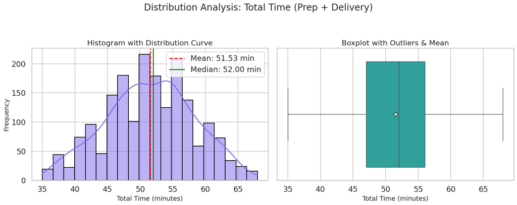

```python
# the new column
df['total_time'] = df['food_preparation_time'] + df['delivery_time']

# style
sns.set(style="whitegrid", context="talk")

# figure with main title
plt.figure(figsize=(16, 6))
plt.suptitle('Distribution Analysis: Total Time (Prep + Delivery)', fontsize=20, weight='light', y=1.05)

# --- Plot 1: Histogram with KDE and Stat Lines ---
plt.subplot(1, 2, 1)

# stats for lines
mean_val = df['total_time'].mean()
median_val = df['total_time'].median()

# Histogram
sns.histplot(
    data=df,
    x='total_time',
    kde=True,
    bins=20,
    color='mediumslateblue',
    edgecolor='black',
    line_kws={'linewidth': 2, 'color': 'darkblue'}
)

# Vertical lines for Mean and Median
plt.axvline(mean_val, color='red', linestyle='--', linewidth=2, label=f'Mean: {mean_val:.2f} min')
plt.axvline(median_val, color='green', linestyle='-', linewidth=2, label=f'Median: {median_val:.2f} min')

# Labelling
plt.title('Histogram with Distribution Curve', fontsize=16)
plt.xlabel('Total Time (minutes)', fontsize=14)
plt.ylabel('Frequency', fontsize=14)
plt.legend()

# --- Plot 2: Boxplot with Custom Outliers ---
plt.subplot(1, 2, 2)

# Boxplot
sns.boxplot(
    data=df,
    x='total_time',
    color='lightseagreen',
    flierprops={"marker": "o", "markerfacecolor": "red", "markersize": 6, "markeredgecolor": "black"},
    showmeans=True,
    meanprops={"marker": "D", "markerfacecolor": "white", "markeredgecolor": "black"}
)

# Labelling
plt.title('Boxplot with Outliers & Mean', fontsize=16)
plt.xlabel('Total Time (minutes)', fontsize=14)

# Adjust layout
plt.tight_layout()
plt.show()
```

### 🔭 My Observations:

- Total order fulfillment time is centered around **~52 minutes**, with mean and median closely aligned.
- Most orders are completed within the **45–60 minute** window, indicating predictable end-to-end performance.
- Variability is moderate, with no extreme outliers, suggesting **stable coordination between restaurants and delivery partners**.
- Total time reflects the combined consistency observed in both preparation and delivery phases.

## Popular cuisine on weekends

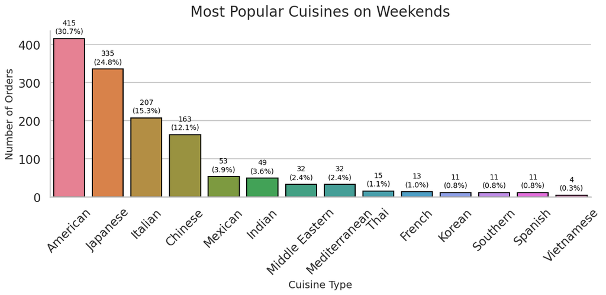

```python
# Filter data for weekends
df_weekend = df[df['day_of_the_week'] == 'Weekend']

# Set style
sns.set(style="whitegrid", context="talk")

plt.figure(figsize=(12, 6))

# the order (Most popular first)
order_weekend = df_weekend['cuisine_type'].value_counts().index

#  Countplot
ax = sns.countplot(
    data=df_weekend,
    x='cuisine_type',
    order=order_weekend,
    palette='husl',
    edgecolor='black'
)

# Titles and Labels
plt.title('Most Popular Cuisines on Weekends', fontsize=20, weight='light', pad=20)
plt.xlabel('Cuisine Type', fontsize=14)
plt.ylabel('Number of Orders', fontsize=14)

# Rotate labels for readability
plt.xticks(rotation=45)

# Counts AND Percentages
total = len(df_weekend)
for p in ax.patches:
    count = int(p.get_height())
    percentage = (count / total) * 100

    ax.annotate(f'{count}\n({percentage:.1f}%)',
                (p.get_x() + p.get_width() / 2., p.get_height()),
                ha='center', va='bottom',
                fontsize=10, fontweight='light', color='black',
                xytext=(0, 5), textcoords='offset points')

# Clean layout
sns.despine()
plt.tight_layout()
plt.show()
```

### 🔭 My Observations:

- Weekend demand is **highly concentrated**, with **American and Japanese cuisines** leading order volume.
- **Italian and Chinese cuisines** also show strong weekend popularity, forming the core demand cluster.
- These top four cuisines account for the **majority of weekend orders**, reinforcing their revenue importance.
- Niche cuisines contribute minimally, reflecting a clear **long-tail demand pattern** during weekends.

## Percentage of Orders Costing More Than $20

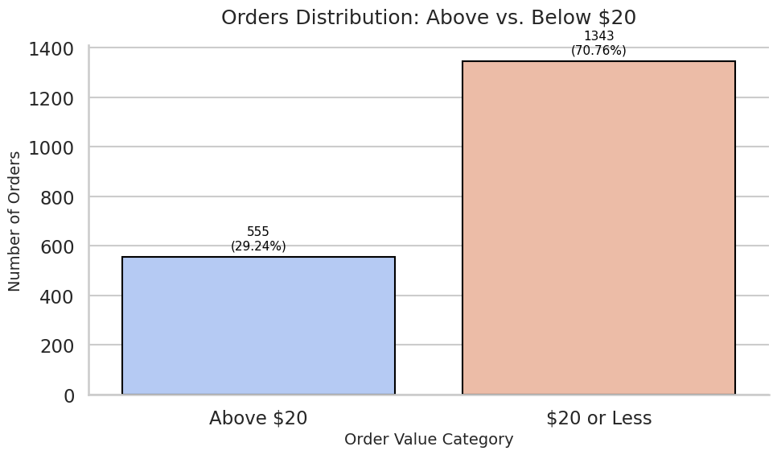

```python
# Set style
sns.set(style="whitegrid", context="talk")

plt.figure(figsize=(10, 6))

# a temporary category for plotting
# This helps group the data into two distinct buckets
df['cost_category'] = df['cost_of_the_order'].apply(lambda x: 'Above $20' if x > 20 else '$20 or Less')

# Countplot
ax = sns.countplot(
    data=df,
    x='cost_category',
    palette='coolwarm',
    edgecolor='black'
)

# Titles and Labels
plt.title('Orders Distribution: Above vs. Below $20', fontsize=18, weight='light', pad=20)
plt.xlabel('Order Value Category', fontsize=14)
plt.ylabel('Number of Orders', fontsize=14)

# Counts and Percentages
total = len(df)
for p in ax.patches:
    count = int(p.get_height())
    percentage = (count / total) * 100

    # text above bar
    ax.annotate(f'{count}\n({percentage:.2f}%)',
                (p.get_x() + p.get_width() / 2., p.get_height()),
                ha='center', va='bottom',
                fontsize=11, fontweight='light', color='black',
                xytext=(0, 5), textcoords='offset points')

# Clean layout
sns.despine()
plt.tight_layout()
plt.show()
```

### 🔭 My Observations:

- A clear majority of orders (**~71%**) are priced at **$20 or less**, indicating strong demand for mid-to-low value orders.
- Higher-value orders (**>$20**) account for **~29%** of total transactions.
- This suggests that revenue volume is driven by **high-frequency, lower-priced orders**, while premium orders contribute selectively.
- Pricing and promotions should primarily target the **sub-$20 segment** to maximize order volume.

## Mean Delivery Time

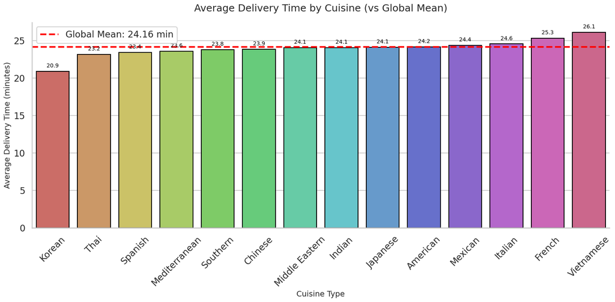

```
The mean delivery time for this dataset is 24.16 minutes
```

```python
# Set style
sns.set(style="whitegrid", context="talk")

plt.figure(figsize=(16, 8))

# the Global Mean
global_mean = df['delivery_time'].mean()

# Bar Plot (showing Mean Delivery Time by Cuisine)
order_by_time = df.groupby('cuisine_type')['delivery_time'].mean().sort_values().index

ax = sns.barplot(
    data=df,
    x='cuisine_type',
    y='delivery_time',
    order=order_by_time,
    palette='hls',
    edgecolor='black',
    errorbar=None # Hides the confidence interval lines for a cleaner look
)

# the Global Mean Reference Line
plt.axhline(global_mean, color='red', linestyle='--', linewidth=3, label=f'Global Mean: {global_mean:.2f} min')

# Titles and Labels
plt.title('Average Delivery Time by Cuisine (vs Global Mean)', fontsize=18, weight='light', pad=20)
plt.xlabel('Cuisine Type', fontsize=14)
plt.ylabel('Average Delivery Time (minutes)', fontsize=14)
plt.legend(loc='upper left', frameon=True, fancybox=True, framealpha=0.9)

# Add data labels on bars
for p in ax.patches:
    height = p.get_height()
    ax.annotate(f'{height:.1f}',
                (p.get_x() + p.get_width() / 2., height),
                ha='center', va='bottom',
                fontsize=10, fontweight='light', color='black',
                xytext=(0, 5), textcoords='offset points')

# Rotate x-axis labels
plt.xticks(rotation=45)

sns.despine()
plt.tight_layout()
plt.show()

# Print the text result as well
print(f"The mean delivery time for this dataset is {round(global_mean, 2)} minutes")
```

### 🔭 My Observations:

- Average delivery times across cuisines are **closely clustered around the global mean (~24.2 minutes)**.
- **Korean cuisine** shows the fastest average delivery time, performing well below the global average.
- **Vietnamese and French cuisines** have relatively higher average delivery times, exceeding the global mean.
- Overall variation across cuisines is limited, indicating **consistent delivery performance regardless of cuisine type**.
- Minor differences may be influenced by **restaurant density or preparation complexity** rather than systemic delivery issues.

## Top 5 Most Frequent Customers

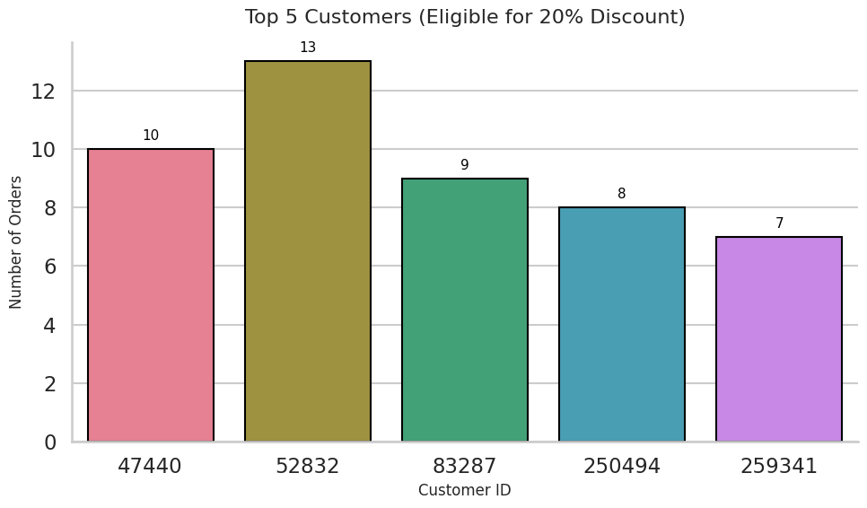

```
Customer IDs eligible for discount:
[52832, 47440, 83287, 250494, 259341]
```

```python
# Set style
sns.set(style="whitegrid", context="talk")

plt.figure(figsize=(10, 6))

# the Top 5 Customers
# .head(5) gets the top 5
top_customers = df['customer_id'].value_counts().head(5)

# the Bar Plot
# converting the Series to a plot
ax = sns.barplot(
    x=top_customers.index,
    y=top_customers.values,
    palette='husl',
    edgecolor='black'
)

# Titles and Labels
plt.title('Top 5 Customers (Eligible for 20% Discount)', fontsize=16, weight='light', pad=15)
plt.xlabel('Customer ID', fontsize=12)
plt.ylabel('Number of Orders', fontsize=12)

# exact counts on top of bars
for p in ax.patches:
    height = int(p.get_height())
    ax.annotate(f'{height}',
                (p.get_x() + p.get_width() / 2., height),
                ha='center', va='bottom',
                fontsize=11, fontweight='light', color='black',
                xytext=(0, 5), textcoords='offset points')

# Clean layout
sns.despine()
plt.tight_layout()
plt.show()

# Print IDs
print("Customer IDs eligible for discount:")
print(top_customers.index.tolist())
```

### 🔭 My Observations:

- A small group of customers demonstrates **higher repeat-order behavior** compared to the rest of the user base.
- The top 5 customers have placed **7–13 orders each**, making them strong candidates for loyalty incentives.
- The following customer IDs are **eligible for a 20% discount** based on order frequency:  
  **[52832, 47440, 83287, 250494, 259341]**
- Targeted discounts for these customers can help **improve retention and lifetime value**.

# Phase-5: Exploratory Data Analysis (Multivariate)

## Cost Distribution vs. Cuisine Type

```python
# Interactive Plotly Plot
```

```python
fig = px.box(
    df,
    x='cuisine_type',
    y='cost_of_the_order',
    color='cuisine_type',
    title='Order Cost Distribution by Cuisine',
)

fig.update_layout(
    xaxis_title='Cuisine Type',
    yaxis_title='Order Cost ($)',
    showlegend=False,
    template='plotly_white'
)

fig.show()
```

[interactive chart not shown]

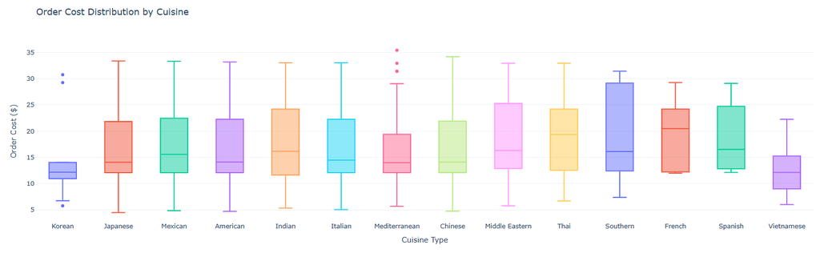

### 🔭 My Observations:

- Order cost varies noticeably across cuisines, indicating **distinct pricing patterns** by cuisine type.
- **French and Thai cuisines** show higher median order costs compared to others.
- **Vietnamese and Korean cuisines** tend to have lower median costs, suggesting more budget-friendly offerings.
- Some cuisines exhibit **wider cost dispersion**, reflecting mixed pricing strategies or varied menu options.
- These differences can inform **cuisine-specific pricing, promotions, and customer targeting strategies**.

## Relationship between 'day of the week' and Delivery Time / Food Preparation Time / Total Time

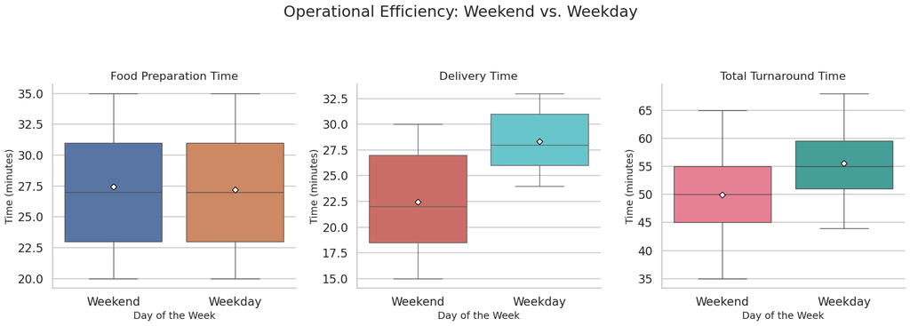

```python
# total_time column
df['total_time'] = df['food_preparation_time'] + df['delivery_time']

# Set style
sns.set(style="whitegrid", context="talk")

plt.figure(figsize=(18, 6))
plt.suptitle('Operational Efficiency: Weekend vs. Weekday', fontsize=22, weight='light', y=1.08)

# --- Plot 1: Food Preparation Time ---
plt.subplot(1, 3, 1)
sns.boxplot(
    data=df,
    x='day_of_the_week',
    y='food_preparation_time',
    hue='day_of_the_week',
    palette='deep',
    showmeans=True,
    meanprops={"marker": "D", "markerfacecolor": "white", "markeredgecolor": "black"}
)
plt.title('Food Preparation Time', fontsize=16, weight='light')
plt.xlabel('Day of the Week', fontsize=14)
plt.ylabel('Time (minutes)', fontsize=14)
# Remove redundant legend
plt.legend([],[], frameon=False)

# --- Plot 2: Delivery Time ---
plt.subplot(1, 3, 2)
sns.boxplot(
    data=df,
    x='day_of_the_week',
    y='delivery_time',
    hue='day_of_the_week',
    palette='hls',
    showmeans=True,
    meanprops={"marker": "D", "markerfacecolor": "white", "markeredgecolor": "black"}
)
plt.title('Delivery Time', fontsize=16, weight='light')
plt.xlabel('Day of the Week', fontsize=14)
plt.ylabel('Time (minutes)', fontsize=14)
plt.legend([],[], frameon=False)

# --- Plot 3: Total Time ---
plt.subplot(1, 3, 3)
sns.boxplot(
    data=df,
    x='day_of_the_week',
    y='total_time',
    hue='day_of_the_week',
    palette='husl',
    showmeans=True,
    meanprops={"marker": "D", "markerfacecolor": "white", "markeredgecolor": "black"}
)
plt.title('Total Turnaround Time', fontsize=16, weight='light')
plt.xlabel('Day of the Week', fontsize=14)
plt.ylabel('Time (minutes)', fontsize=14)
plt.legend([],[], frameon=False)

# Clean up layout
sns.despine()
plt.tight_layout()
plt.show()
```

### 🔭 My Observations:

- **Food preparation time** is nearly identical on weekends and weekdays, indicating consistent restaurant performance.
- **Delivery time** is noticeably **faster on weekends** compared to weekdays.
- As a result, **total turnaround time** is lower on weekends despite higher order volumes.
- This suggests that **traffic conditions or better delivery partner availability** on weekends offset the increased demand.
- Weekday delivery operations present an opportunity for efficiency improvement.

## Revenue Generated by Top 10 Restaurants

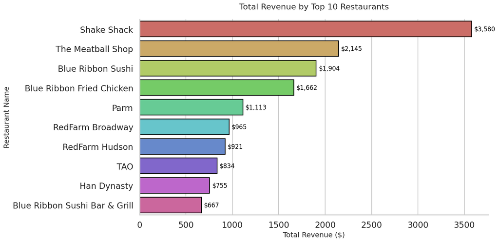

```
-----------------------------------------
Top 5 Revenue Generating Restaurants:
restaurant_name
Shake Shack                  3579.53
The Meatball Shop            2145.21
Blue Ribbon Sushi            1903.95
Blue Ribbon Fried Chicken    1662.29
Parm                         1112.76
Name: cost_of_the_order, dtype: float64
-----------------------------------------
```

```python
# Set style
sns.set(style="whitegrid", context="talk")

plt.figure(figsize=(14, 7))

# Aggregate and Sort Data
# Group by restaurant, sum the cost, sort descending, take top 10
revenue_data = df.groupby(['restaurant_name'])['cost_of_the_order'].sum().sort_values(ascending=False).head(10)

# Horizontal Bar Plot
ax = sns.barplot(
    x=revenue_data.values,
    y=revenue_data.index,
    palette='hls',
    edgecolor='black'
)

# Titles and Labels
plt.title('Total Revenue by Top 10 Restaurants', fontsize=16, weight='light', pad=20)
plt.xlabel('Total Revenue ($)', fontsize=14)
plt.ylabel('Restaurant Name', fontsize=14)

# Revenue Labels to Bars
for p in ax.patches:
    width = p.get_width()
    # Format as currency (e.g., $1,200)
    ax.annotate(f'${width:,.0f}',
                (width, p.get_y() + p.get_height() / 2.),
                ha='left', va='center',
                fontsize=12, fontweight='light', color='black',
                xytext=(5, 0), textcoords='offset points')

# Clean layout
sns.despine()
plt.tight_layout()
plt.show()


print("-----------------------------------------")
# Print the exact values for reference
print("Top 5 Revenue Generating Restaurants:")
print(revenue_data.head(5))
print("-----------------------------------------")
```

### 🔭 My Observations:

- Revenue generation is **highly concentrated among a small set of restaurants**.
- **Shake Shack** is the top revenue contributor by a wide margin, followed by **The Meatball Shop** and **Blue Ribbon Sushi**.
- The **top 5 restaurants** contribute a substantial share of total platform revenue.
- This concentration highlights the importance of **strategic partnerships and retention** of high-performing restaurants.
- Supporting mid-tier restaurants to scale can help **reduce revenue dependency risk**.

## Customer Ratings on Key Metrics

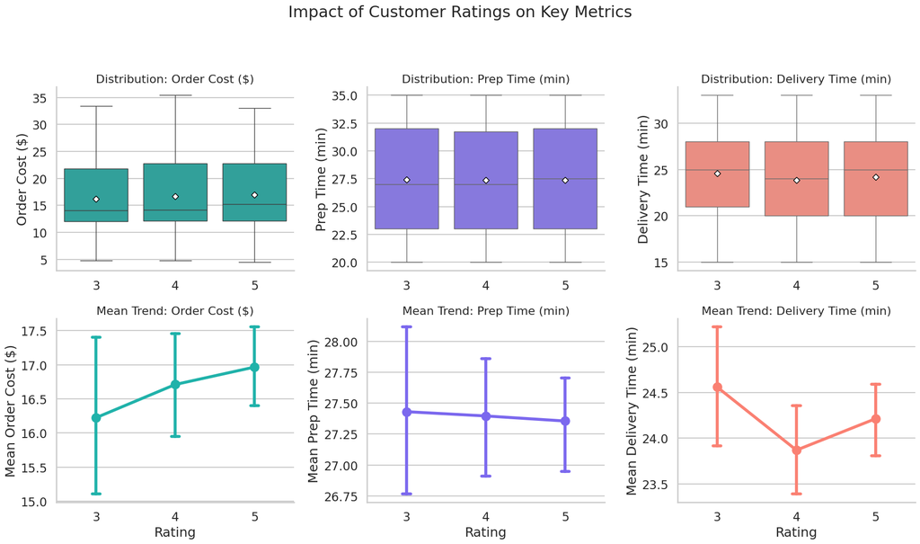

```python
# Data for valid ratings only
df_rated = df[df['rating'] != 'Not given'].copy()
rating_order = ['3', '4', '5']

# Set style
sns.set(style="whitegrid", context="talk")

# 2x3 grid
fig, axes = plt.subplots(2, 3, figsize=(18, 10))
fig.suptitle('Impact of Customer Ratings on Key Metrics', fontsize=22, weight='light', y=1.05)

# Metrics Configuration
metrics = ['cost_of_the_order', 'food_preparation_time', 'delivery_time']
titles = ['Order Cost ($)', 'Prep Time (min)', 'Delivery Time (min)']
colors = ['lightseagreen', 'mediumslateblue', 'salmon']  # Distinct color for each column

for i, (col, title, color) in enumerate(zip(metrics, titles, colors)):

    # --- Row 1: Boxplots (Distribution) ---
    sns.boxplot(
        ax=axes[0, i],
        data=df_rated,
        x='rating',
        y=col,
        order=rating_order,
        color=color,
        showmeans=True,
        meanprops={"marker": "D", "markerfacecolor": "white", "markeredgecolor": "black"}
    )
    axes[0, i].set_title(f'Distribution: {title}', fontsize=16)
    axes[0, i].set_xlabel('')
    axes[0, i].set_ylabel(title)

    # --- Row 2: Pointplots (Mean Trend) ---
    sns.pointplot(
        ax=axes[1, i],
        data=df_rated,
        x='rating',
        y=col,
        order=rating_order,
        color=color,
        markers='o',
        capsize=0.1
    )
    axes[1, i].set_title(f'Mean Trend: {title}', fontsize=16)
    axes[1, i].set_xlabel('Rating')
    axes[1, i].set_ylabel(f'Mean {title}')

# Clean up layout
sns.despine()
plt.tight_layout()
plt.show()
```

## Correlation Matrix

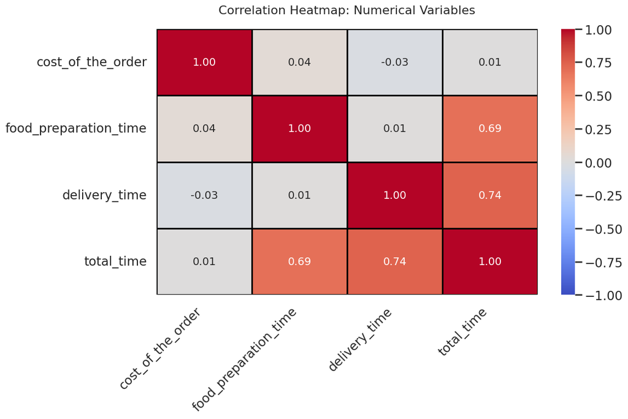

```python
# Set style
sns.set(style="whitegrid", context="talk")

plt.figure(figsize=(12, 8))

#  Numerical Columns
numerical_cols = ['cost_of_the_order', 'food_preparation_time', 'delivery_time', 'total_time']

# Calculate Correlation
corr_matrix = df[numerical_cols].corr()

# Heatmap
# vmin=-1, vmax=1 ensures the color scale is centered at 0 (white)
sns.heatmap(
    corr_matrix,
    annot=True,
    cmap='coolwarm',
    fmt=".2f",
    linewidths=1,
    linecolor='black',
    vmin=-1,
    vmax=1,
    annot_kws={"size": 14, "weight": "light"}
)

# Titles and Labels
plt.title('Correlation Heatmap: Numerical Variables', fontsize=16, weight='light', pad=20)

# Rotate x-axis labels for better readability
plt.xticks(rotation=45, ha='right')
plt.yticks(rotation=0)

plt.tight_layout()
plt.show()
```

### 🔭 My Observations:

- **Total time** shows a strong positive correlation with both **delivery time (0.74)** and **food preparation time (0.69)**.
- **Delivery time** has a slightly stronger influence on total turnaround time than preparation time.
- **Order cost** exhibits **negligible correlation** with time-based variables, indicating pricing is independent of operational duration.
- Overall, **delivery efficiency is the primary driver** of end-to-end order completion time.

## High-Performing Restaurants

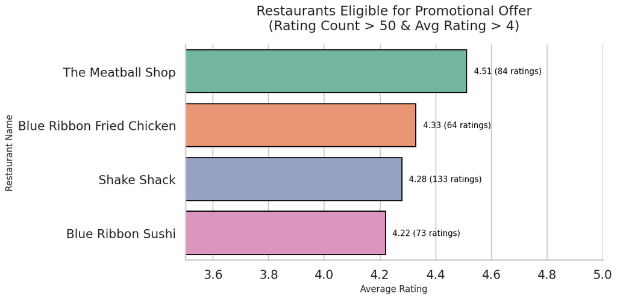

```
------------------------------
Qualified Restaurants:
- The Meatball Shop
- Blue Ribbon Fried Chicken
- Shake Shack
- Blue Ribbon Sushi
------------------------------
```

```python
# Set style
sns.set(style="whitegrid", context="talk")

# Filter out 'Not given' and convert to integer
df_rated = df[df['rating'] != 'Not given'].copy()
df_rated['rating'] = df_rated['rating'].astype(int)

# Group by Restaurant Name and calculate both Count and Mean
# .agg() allows us to do both in one step
restaurant_stats = df_rated.groupby('restaurant_name')['rating'].agg(['count', 'mean']).reset_index()

# the Promotional Criteria
# Condition: Count > 50 AND Mean Rating > 4
qualified_restaurants = restaurant_stats[
    (restaurant_stats['count'] > 50) &
    (restaurant_stats['mean'] > 4)
].sort_values(by='mean', ascending=False)

# Visualization
plt.figure(figsize=(12, 6))

# Horizontal bar chart of the Average Rating
ax = sns.barplot(
    data=qualified_restaurants,
    x='mean',
    y='restaurant_name',
    palette='Set2',
    edgecolor='black'
)

# Titles and Labels
plt.title('Restaurants Eligible for Promotional Offer\n(Rating Count > 50 & Avg Rating > 4)',
          fontsize=18, weight='light', pad=20)
plt.xlabel('Average Rating', fontsize=12)
plt.ylabel('Restaurant Name', fontsize=12)
plt.xlim(3.5, 5.0) # Zoom in on the rating scale (since all are > 4)

# Data Labels (Avg Rating + Total Count)
for p, count, name in zip(ax.patches, qualified_restaurants['count'], qualified_restaurants['restaurant_name']):
    width = p.get_width()
    # Label format: "4.32 (120 reviews)"
    ax.annotate(f'{width:.2f} ({count} ratings)',
                (width, p.get_y() + p.get_height() / 2.),
                ha='left', va='center',
                fontsize=11, fontweight='light', color='black',
                xytext=(10, 0), textcoords='offset points')

# Clean layout
sns.despine()
plt.tight_layout()
plt.show()

# Print the names
print("------------------------------")
print("Qualified Restaurants:")
for name in qualified_restaurants['restaurant_name']:
    print(f"- {name}")
print("------------------------------")
```

### 🔭 My Observations:

- Only **four restaurants** meet the promotional eligibility criteria (**rating count > 50** and **average rating > 4**).
- **The Meatball Shop** leads with the highest average rating, indicating strong and consistent customer satisfaction.
- **Shake Shack** combines high ratings with a large number of reviews, reflecting both **popularity and reliability**.
- The limited number of eligible restaurants highlights a **quality concentration**, suggesting scope to uplift other partners through performance improvement initiatives.

## Net Revenue

```
---------------------------------------
The net revenue generated is: $6,166.30
---------------------------------------
```

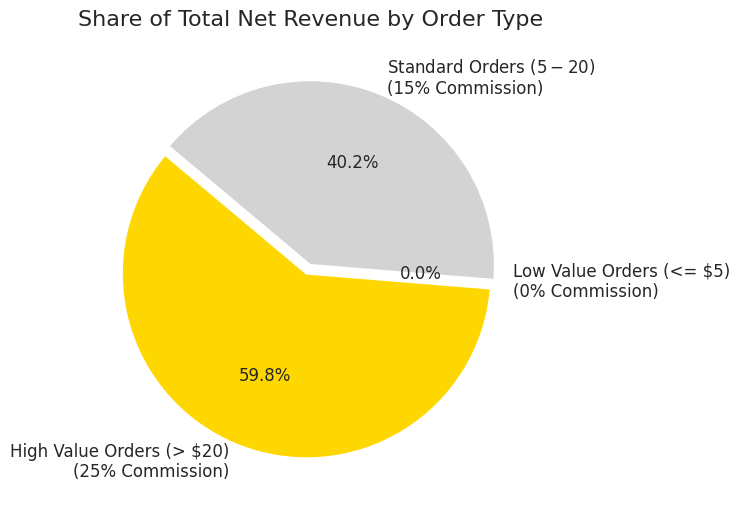

```python
# the Revenue Function
def compute_rev(x):
    if x > 20:
        return x * 0.25  # 25% commission
    elif x > 5:
        return x * 0.15  # 15% commission
    else:
        return x * 0     # No commission

# Apply the function to create a new 'Revenue' column
df['Revenue'] = df['cost_of_the_order'].apply(compute_rev)

# Calculate and Print Total Net Revenue
total_rev = df['Revenue'].sum()
print(f"---------------------------------------")
print(f"The net revenue generated is: ${total_rev:,.2f}")
print(f"---------------------------------------")

# --- Revenue Source Analysis ---

# a categorization column just for plotting
def get_revenue_tier(x):
    if x > 20:
        return 'High Value Orders (> $20)\n(25% Commission)'
    elif x > 5:
        return 'Standard Orders ($5 - $20)\n(15% Commission)'
    else:
        return 'Low Value Orders (<= $5)\n(0% Commission)'

df['Revenue_Tier'] = df['cost_of_the_order'].apply(get_revenue_tier)

# Aggregate revenue by tier
revenue_by_tier = df.groupby('Revenue_Tier')['Revenue'].sum()

# a Pie Chart to show Revenue Share
plt.figure(figsize=(8, 6))
plt.pie(
    revenue_by_tier,
    labels=revenue_by_tier.index,
    autopct='%1.1f%%',
    colors=['gold', 'mediumslateblue', 'lightgray'], # Distinct colors for money
    startangle=140,
    explode=(0.05, 0, 0),
    textprops={'fontsize': 12, 'weight': 'light'}
)

plt.title('Share of Total Net Revenue by Order Type', fontsize=16, weight='light')
plt.show()
```

### 🔭 My Observations:

- **High-value orders (>$20)** contribute the **largest share of net revenue (~60%)**, despite being fewer in number.
- **Standard orders ($5–$20)** account for roughly **40% of net revenue**, forming a stable revenue base.
- **Low-value orders (≤ $5)** contribute **negligible revenue**, offering limited margin impact.
- The **total net revenue generated is $6,166.30**.
- Revenue optimization efforts should prioritize **upselling and conversion to high-value orders** rather than increasing low-value transactions.

## Percentage of Orders Taking > 60 Minutes

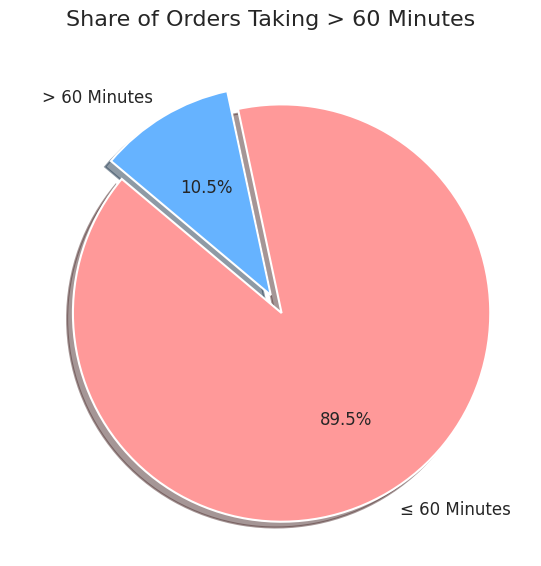

```
---------------------------------------------------------------
The percentage of orders taking more than 60 minutes is: 10.54%
---------------------------------------------------------------
```

```python
# the 'total_time' column
df['total_time'] = df['food_preparation_time'] + df['delivery_time']

# Categorize data for the plot
df['time_category'] = df['total_time'].apply(lambda x: '> 60 Minutes' if x > 60 else '≤ 60 Minutes')
counts = df['time_category'].value_counts()

# Pie Chart
plt.figure(figsize=(10, 6))

colors = ['#ff9999', '#66b3ff']

plt.pie(
    counts,
    labels=counts.index,
    autopct='%1.1f%%',
    colors=colors,
    startangle=140,
    explode=(0.1, 0),  # "Explode" the first slice to make it stand out
    shadow=True,
    textprops={'fontsize': 12, 'weight': 'light'}
)

# Titles
plt.title('Share of Orders Taking > 60 Minutes', fontsize=16, weight='light')

plt.tight_layout()
plt.show()

# Print the exact calculation
percentage = (df[df['total_time'] > 60].shape[0] / df.shape[0]) * 100
print(f"---------------------------------------------------------------")
print(f"The percentage of orders taking more than 60 minutes is: {round(percentage, 2)}%")
print(f"---------------------------------------------------------------")
```

### 🔭 My Observations:

- Approximately **10.54% of orders** take **more than 60 minutes** to complete.
- The vast majority of orders (**~89.5%**) are delivered within **60 minutes**, indicating generally strong operational performance.
- Orders exceeding 60 minutes represent a **critical risk segment** for customer dissatisfaction and churn.
- Targeted interventions for these delayed orders can significantly improve **customer experience and retention**.

## Mean Delivery Time: Weekday vs. Weekend.

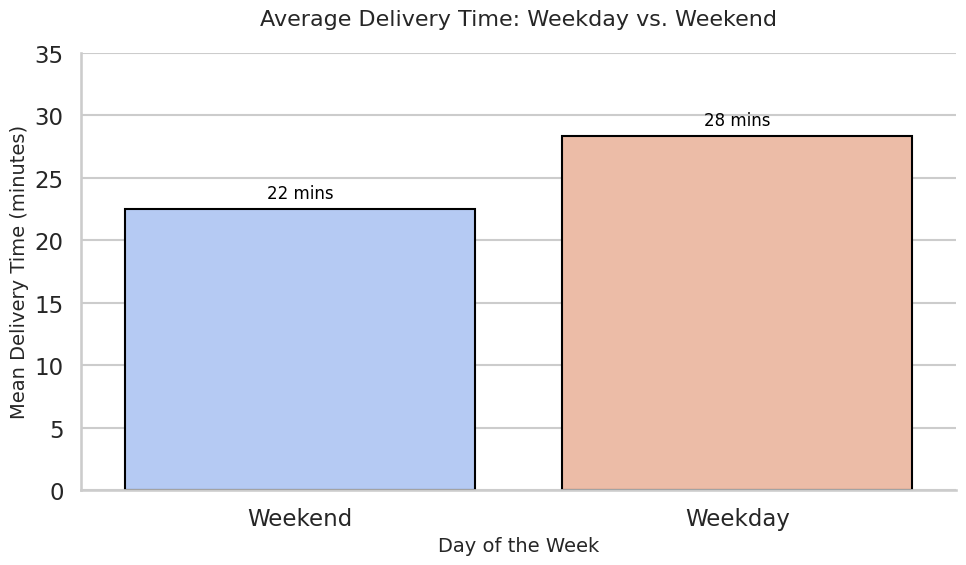

```
-------------------------------------------------------
The mean delivery time on weekdays is around 28 minutes
The mean delivery time on weekends is around 22 minutes
-------------------------------------------------------
```

```python
# Set style
sns.set(style="whitegrid", context="talk")

plt.figure(figsize=(10, 6))

# Bar Plot
# estimator=np.mean calculates the average automatically
# ci=None removes the error bars (confidence intervals) to focus just on the mean
ax = sns.barplot(
    data=df,
    x='day_of_the_week',
    y='delivery_time',
    palette='coolwarm',
    estimator=np.mean,
    ci=None,
    edgecolor='black'
)

# Titles and Labels
plt.title('Average Delivery Time: Weekday vs. Weekend', fontsize=16, weight='light', pad=20)
plt.xlabel('Day of the Week', fontsize=14)
plt.ylabel('Mean Delivery Time (minutes)', fontsize=14)
plt.ylim(0, 35) # Set limit to give space for labels

# Data Labels (The exact means)
for p in ax.patches:
    height = p.get_height()
    # Formatting to matching your print statement (rounded integer)
    ax.annotate(f'{round(height)} mins',
                (p.get_x() + p.get_width() / 2., height),
                ha='center', va='bottom',
                fontsize=12, fontweight='light', color='black',
                xytext=(0, 5), textcoords='offset points')

# Clean layout
sns.despine()
plt.tight_layout()
plt.show()

# Print the text statements
weekday_mean = df[df['day_of_the_week'] == 'Weekday']['delivery_time'].mean()
weekend_mean = df[df['day_of_the_week'] == 'Weekend']['delivery_time'].mean()


print(f"-------------------------------------------------------")
print(f"The mean delivery time on weekdays is around {round(weekday_mean)} minutes")
print(f"The mean delivery time on weekends is around {round(weekend_mean)} minutes")
print(f"-------------------------------------------------------")
```

### 🔭 My Observations:

- The **mean delivery time on weekdays** is approximately **28 minutes**.
- The **mean delivery time on weekends** is significantly lower at around **22 minutes**.
- Despite higher order volumes on weekends, delivery performance is **more efficient**, likely due to better traffic conditions or delivery partner availability.
- Weekday delivery operations represent a **clear optimization opportunity**.

## Demand Dynamics: Cuisine Popularity Split by Day

```python
# Interactive Plotly Plot
```

```python
# visual template
pio.templates.default = "plotly_white"
```

```python
df['rating_numeric'] = pd.to_numeric(df['rating'], errors='coerce')
df['rating_category'] = df['rating'].replace('Not given', 'Unrated')
```

```python
cuisine_day_counts = df.groupby(['cuisine_type', 'day_of_the_week']).size().reset_index(name='count')

fig1 = px.bar(
    cuisine_day_counts,
    x='cuisine_type',
    y='count',
    color='day_of_the_week',
    title='Cuisine Demand: The Weekend Surge Effect',
    labels={'count': 'Order Volume', 'cuisine_type': 'Cuisine', 'day_of_the_week': 'Period'},
    color_discrete_map={'Weekend': '#FF5733', 'Weekday': '#3366CC'}, # Unique high-contrast colors
    barmode='stack',
    text_auto=True
)
fig1.update_layout(
    title_font_size=20,
    xaxis_tickangle=-45,
    legend=dict(title="Time of Week", orientation="h", y=1.5, x=1)
)
fig1.show()
```

[interactive chart not shown]

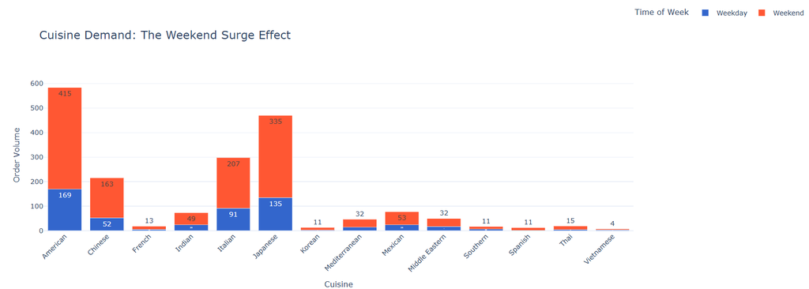

### 🔭 My Observations:

- Order volumes are consistently **higher on weekends across all cuisines**, reinforcing strong weekend-driven demand.
- **American, Japanese, and Italian cuisines** dominate both weekday and weekend orders, with a pronounced weekend surge.
- Niche cuisines show **low but stable demand**, indicating limited sensitivity to day-of-week effects.
- The clear weekend uplift highlights opportunities for **targeted promotions and capacity planning** during weekends.

## Operational Matrix: Efficiency vs. Satisfaction

```python
# Interactive Plotly Plot
```

```python
# Correlates speed (Prep + Delivery) with Customer Satisfaction (Rating).
df_rated = df.dropna(subset=['rating_numeric'])

fig2 = px.scatter(
    df_rated,
    x='food_preparation_time',
    y='delivery_time',
    size='cost_of_the_order',  # Bubble size = Revenue
    color='rating_numeric',    # Color = Customer Satisfaction
    hover_name='restaurant_name',
    hover_data=['cuisine_type', 'day_of_the_week'],
    title='Operational Matrix: Efficiency vs. Rating<i>(Size = Order Value, Color = Rating 3-5)</i>',
    labels={
        'food_preparation_time': 'Kitchen Prep Time (min)',
        'delivery_time': 'Last-Mile Delivery Time (min)',
        'rating_numeric': 'Rating'
    },
    color_continuous_scale='Viridis'
)

# Threshold Lines (Business Logic: >30 mins is "Slow")
fig2.add_hline(y=30, line_dash="dash", line_color="red", annotation_text="Delivery Threshold (30m)")
fig2.add_vline(x=30, line_dash="dash", line_color="red", annotation_text="Prep Threshold (30m)")
fig2.update_layout(height=600)
fig2.show()
```

[interactive chart not shown]

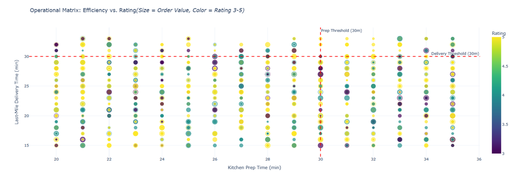

## Market Share Sunburst: The "Power" Restaurants

```python
# Interactive Plotly Plot
```

```python
# Hierarchical view of Revenue > Restaurant > Cuisine
# Grouping data for the sunburst
df_sunburst = df.groupby(['cuisine_type', 'restaurant_name'])['cost_of_the_order'].sum().reset_index()
top_cuisines = df_sunburst.groupby('cuisine_type')['cost_of_the_order'].sum().nlargest(5).index
df_sunburst_filtered = df_sunburst[df_sunburst['cuisine_type'].isin(top_cuisines)]

fig4 = px.sunburst(
    df_sunburst_filtered,
    path=['cuisine_type', 'restaurant_name'],
    values='cost_of_the_order',
    title='Revenue Concentration: Top Cuisines & Restaurants',
    color='cost_of_the_order',
    color_continuous_scale='RdBu',
)
fig4.update_layout(margin=dict(t=40, l=0, r=0, b=0))
fig4.show()
```

[interactive chart not shown]

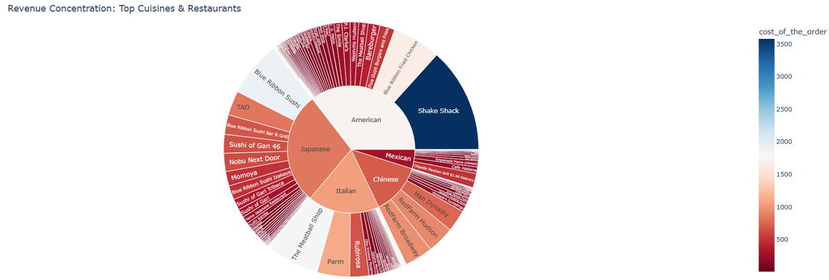

### 🔭 My Observations:

- Revenue is **highly concentrated within a small set of cuisines**, with **American, Japanese, and Italian** dominating total revenue.
- Within each top cuisine, **one or two restaurants contribute a disproportionately large share** of revenue (e.g., Shake Shack in American cuisine).
- A pronounced **long-tail of restaurants** exists within each cuisine, each contributing marginal revenue individually.
- This structure indicates **dependency risk on top-performing restaurants** and highlights opportunities to uplift mid-tier partners to diversify revenue sources.

# Phase-6: Conclusion

The analysis of the **FoodHub dataset** reveals a business strongly influenced by temporal demand patterns and a concentrated set of popular offerings.

## 1. Market Preferences and Demand Concentration

**Cuisine Dominance**  
Approximately **80% of total orders** are concentrated within just four cuisines:

- American
- Japanese
- Italian
- Chinese

This indicates a clear and strong customer preference toward these categories, suggesting high ROI potential for focused promotions and partnerships.

**Restaurant Leadership**  
**Shake Shack** emerges as the most popular restaurant on the platform, contributing the highest order volume and demonstrating strong brand pull.

## 2. Operational Efficiency & Temporal Trends

**Weekend Demand Surge**  
Order volumes rise significantly during weekends compared to weekdays, positioning FoodHub primarily as a **leisure and weekend-driven service**.

**Inverse Delivery Efficiency**  
Contrary to typical logistics expectations, delivery performance improves during peak demand:

- **Weekend average delivery time:** ~22 minutes
- **Weekday average delivery time:** ~28 minutes

This ~6-minute improvement suggests that reduced traffic congestion or higher delivery partner availability on weekends offsets increased order volume.

## 3. Partner Performance Ecosystem

**Elite Quality Tier Scarcity**  
High-performing restaurant partners are limited:

- Only **4 restaurants** met the strict promotional criteria
  - Rating Count > 50
  - Mean Rating > 4

This highlights an opportunity for FoodHub to introduce **partner enablement programs** to help more restaurants reach this elite performance tier.

## 4. Data Quality and Analytical Blind Spots

**The Feedback Gap**  
Approximately **39% of orders remain unrated ("Not given")**, creating a major blind spot in:

- Customer satisfaction analysis
- Accurate restaurant performance evaluation

# Phase-7: Business Recommendations

Based on the analysis, the following strategic actions are recommended to **optimize operations, increase revenue, and improve customer satisfaction**.

## 1. Customer Experience & Retention

### Launch a “Rate Your Meal” Campaign

**Insight:**  
A critical **39% of orders are unrated**, creating a significant data blind spot in customer satisfaction measurement.

**Action:**  
Implement an interactive, gamified rating prompt (e.g., push notification or in-app banner) immediately after delivery.  
Offer small incentives such as:

> *“Earn $5 off your next order after rating 3 meals”*

This will help close the feedback gap and generate more reliable, actionable satisfaction data.

### Implement Proactive Service Recovery

**Insight:**  
Approximately **11% of orders exceed 60 minutes**, making them a major contributor to customer dissatisfaction and churn.

**Action:**  
Automate a **Service Recovery Trigger**:

- If an order remains *“In Progress”* for **55+ minutes**, automatically send:
  - A personalized apology message
  - A compensation coupon (e.g., **15% off next order**)

This approach converts a negative experience into a loyalty-building moment—*before* the customer complains.

## 2. Operational Efficiency

### Optimize Weekday Logistics

**Insight:**  
Mean delivery times are significantly slower on weekdays (**28 mins**) compared to weekends (**22 mins**), despite lower weekday order volume.

**Action:**

- Investigate weekday bottlenecks (traffic congestion, driver availability, routing inefficiencies)
- Introduce **weekday peak-hour incentives** or shift bonuses for delivery partners
- Align weekday staffing levels with the operational efficiency observed on weekends

### Maintain Weekend Capacity

**Action:**  
Since weekends generate the majority of order volume:

- Continue existing staffing and routing strategies
- Monitor saturation thresholds to ensure delivery speed remains consistently high during peak demand

## 3. Marketing & Partnerships

### Capitalize on Cuisine Demand Trends

**Insight:**  
Approximately **80% of orders** come from four cuisines:

- American
- Japanese
- Italian
- Chinese

**Action:**

- Focus marketing spend on onboarding and promoting **high-quality restaurants** within these categories
- Feature a curated **“Best of [Cuisine]”** carousel on the app homepage to streamline discovery for the majority of users

### Create a “Top Partner” Program

**Insight:**  
Only a small subset of restaurants (e.g., Shake Shack) combine **high order volume and strong ratings**.

**Action:**  
Formalize a **FoodHub Top Partner** tier for restaurants meeting:

- **Rating Count > 50**
- **Average Rating > 4.0**

Provide incentives such as:

- Premium app placement
- Co-branded promotions
- Early access to new platform features

This drives more traffic to the most reliable partners while setting a performance benchmark for others.

### Strategic Impact

These recommendations can collectively strengthen **customer loyalty**, **operational reliability**, and **revenue concentration in high-ROI segments**, while addressing key data and service gaps identified during the analysis.